# Stats 102C, Homework 1

JANG,JUNHYUK

SID : 004 728 134

## Problem 1 - Estimate pi (poorly)

Find an estimate of pi by estimating the ratio between the area of a circle and its encompassing square.

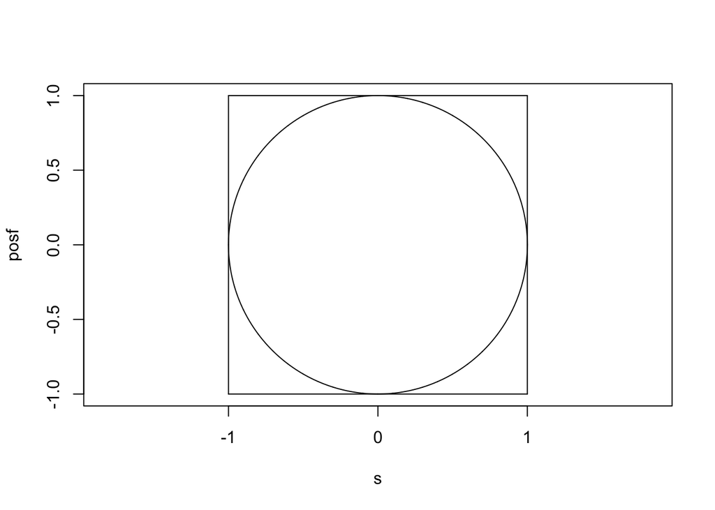

```r
s <- seq(-1,1, by = 0.001)
posf <- sqrt(1-s^2)
plot(s, posf, type = "l", asp = 1, ylim = c(-1,1))
lines(s, -1*posf)
segments(-1,-1,-1,1)
segments(-1,-1,1,-1)
segments(1,1,-1,1)
segments(1,1,1,-1)
```

To calculate the area of the circle analytically, we would need to integrate the function drawing the upper semi-circle and then multiply that by 2. This process requires the use of trig substitutions, and while doable, can illustrate a time where the analytic solution is not easy.

$$Area = 2 \times \int_{-1}^1 \sqrt{1 - x^2} dx$$

For the Monte-Carlo approach, we will use `runif(n, min = -1, max=1)` to generate a bunch of random pairs of x and y coordinates. We will see how many of those random uniform points fall within the circle. This is easy - just see if $x^2 + y^2 \le 1$. The total area of the square is 4. The total area of the circle is pi. Thus, the proportion of coordinates that satisfy the inequality $x^2 + y^2 \le 1 \approx \pi/4$.

Instructions:

- create a vector x of n random values between -1 and 1. I suggest starting with n = 500
- create a vector y of n random values between -1 and 1. Use the two vectors to make coordinate pairs.
- calculate which of points satisfy the inequality for falling inside the circle.
- Print out your estimate of pi by multiplying the proportion by 4.
- plot each of those (x,y) coordinate pairs. Use pch = 20. Color the points based on whether they fall in the circle or not.

```r
set.seed(1)
x <- runif(500,-1,1)
y <- runif(500,-1,1)

x_satis <- c()
y_satis <- c()
satisf <- function(x,y){
        count <- 0
        for(i in 1: length(x)){
                if((x[i])^2 + (y[i])^2 < 1){
                        count <- count + 1
                        x_satis[i] <- x[i]
                        y_satis[i] <- y[i]
                }
        }
        return(list(count = count, x_satis = x_satis, y_satis = y_satis))
}
# The number of total satisfied points among 500
satisf(x,y)$count
```

```
## [1] 401
```

```r
# calculate which of points satisfy the inequality for falling inside the circle.
satis_df <- data.frame(satisfied_x = satisf(x,y)$x_satis,satisfied_y = satisf(x,y)$y_satis)
clean_satis <- na.omit(satis_df)

# Print out your estimate of pi by multiplying the proportion by 4.
(pi <- (satisf(x,y)$count / 500) * 4)
```

```
## [1] 3.208
```

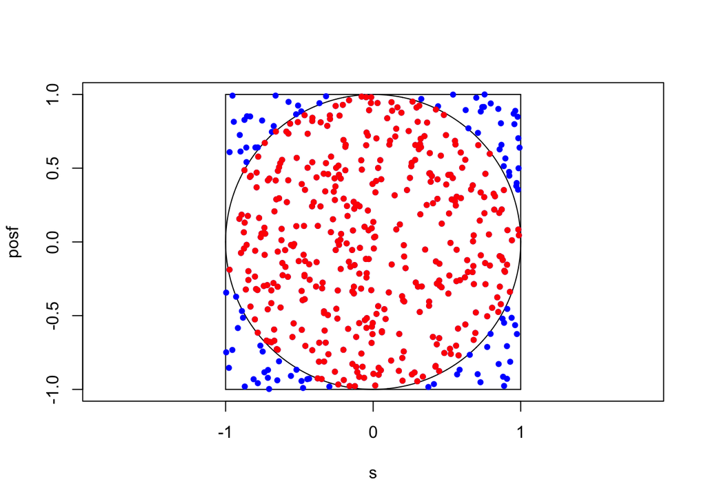

```r
# plot each of those (x,y) coordinate pairs. Use pch = 20.
# Color the points based on whether they fall in the circle or not.
s <- seq(-1,1, by = 0.001)
posf <- sqrt(1-s^2)
plot(s, posf, type = "l", asp = 1, ylim = c(-1,1))
lines(s, -1*posf)
segments(-1,-1,-1,1)
segments(-1,-1,1,-1)
segments(1,1,-1,1)
segments(1,1,1,-1)

points(x,y, col = "blue",pch = 20)
points(clean_satis$satisfied_x,clean_satis$satisfied_y,col = "red",pch = 20)
```

## Problem 2

Generate Random variable from an exponential distribution

Write a function `my_rexp(n, rate)`, that will generate `n` random values drawn from an exponential distribution with lambda = “rate” by using the inverse CDF method. Use `runif()` as your sole source of randomness.

You are not allowed to use any of the functions `dexp()`, `pexp()`, `qexp()`, or `rexp()`.

Use your function to generate 500 random samples from an exponential distribution with lambda = 1.

After generating 500 samples, plot the empirical CDF function of your data (see `ecdf`). Add the theoretic CDF of the exponential distribution to the same plot (in a different color).

Use the Kolmogorov-Smirnov test to compare your generated samples to the theoretic exponential distribution. Be sure to print out the resulting p-value and comment on the sample produced by your function.

```r
my_rexp <- function(n, rate){
  x <- c()
  for(i in 1:n){
          x[i] <- (-1/rate)*log(runif(1))
  }
  return(x)
}
set.seed(1234)
(p <- runif(1))
```

```
## [1] 0.1137034
```

```r
set.seed(1234)
my_rexp(500,1)
```

[output not shown]

[output cut: 85 more lines]

```r
-log(0.8010433)
```

```
## [1] 0.2218403
```

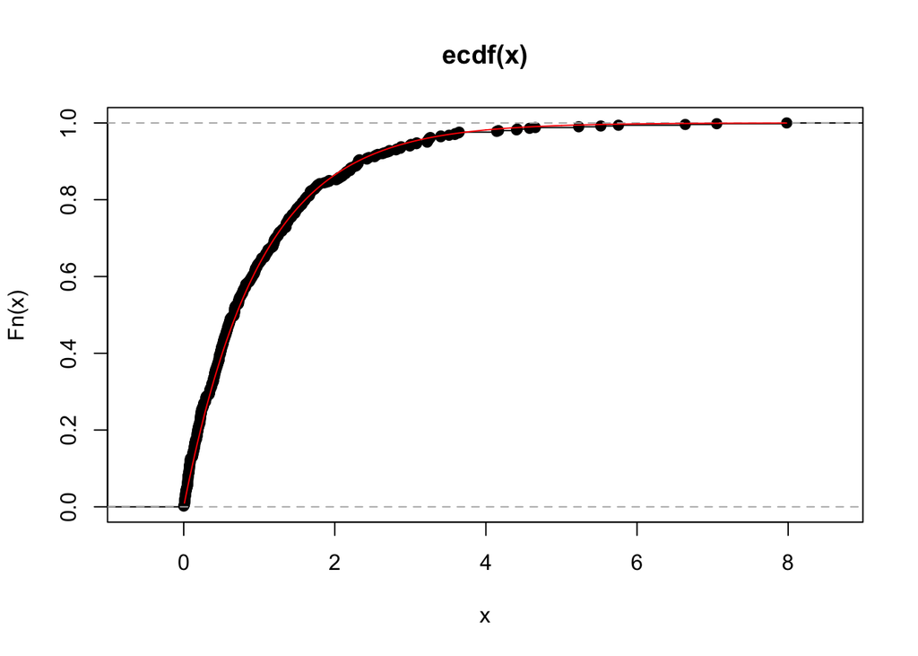

```r
x <- my_rexp(500, rate = 1)
plot(ecdf(x))
vals <- seq(0.01, max(x), by = 0.01)
lines(vals, pexp(vals, rate = 1), col = "red")
```

```r
# ks test
ks.test(x,pexp(500,1))
```

```
##
##  Two-sample Kolmogorov-Smirnov test
##
## data:  x and pexp(500, 1)
## D = 0.634, p-value = 0.7345
## alternative hypothesis: two-sided
```

```r
# Large p-value indicates that there is an insufficient evididence to reject the
# null hypothesis and coclude that the two data come from the
# same distribution.
```

## Problem 3

Generate Random variable from an binomial distribution

Write a function `my_rbinom(n, size, prob)`, that will generate `n` random values drawn from a binomial distribution with size = `size` and probability of success = `prob` by using the inverse CDF method. Use `runif()` as your sole source of randomness.

Do not use any of R’s binom functions. Do not use `dbinom`, `pbinom`, `qbinom()`, or `rbinom()`

Use your function `my_rbinom()` to generate 200 values from a binomial distribution with n = 6, and p = 0.4.

After generating 200 samples, make a side-by-side barchart that shows the empirical PMF of your data and the theoretic PMF according to the binomial distribution.

Use a chi-squared goodness-of-fit test to see if the generated values fit the expected probabilities. Be sure to comment on the graph and results of the test.

```r
# write your code here
# PDF
# p(x=0) = choose(6,0)*(0.4)^0*(0.6)^6 = 0.046656
# p(x=1) = choose(6,1)*(0.4)^1*(0.6)^5 = 0.186624
# p(x=2) = choose(6,2)*(0.4)^2*(0.6)^4 = 0.31104
# p(x=3) = choose(6,3)*(0.4)^3*(0.6)^3 = 0.276480
# p(x=4) = choose(6,4)*(0.4)^4*(0.6)^2 = 0.138240
# p(x=5) = choose(6,5)*(0.4)^5*(0.6)^1 = 0.036864
# p(x=6) = choose(6,6)*(0.4)^6*(0.6)^0 = 0.004096

p <- c(0.046656,0.186624,0.31104,0.276480,0.138240,0.036864,0.004096)
# CDF
(cdf <- cumsum(p))
```

```
## [1] 0.046656 0.233280 0.544320 0.820800 0.959040 0.995904 1.000000
```

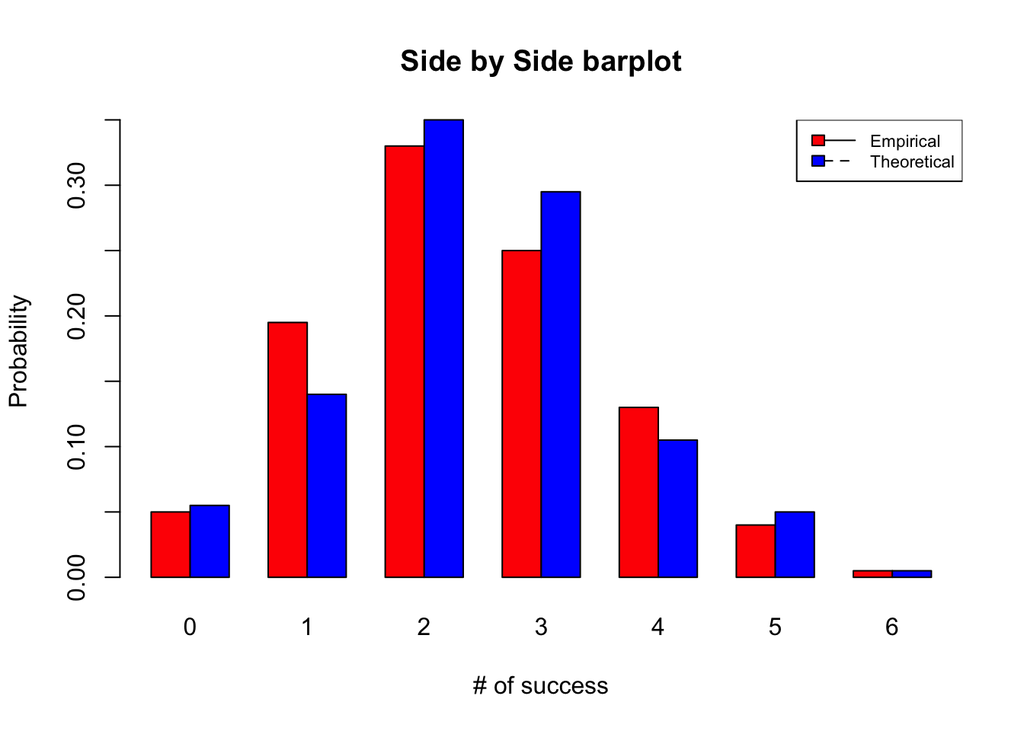

```r
my_binom <- function(n,size,prob){
        c0 <- choose(6,0)*(prob)^0*(1-prob)^6
        c1 <- choose(6,1)*(prob)^1*(1-prob)^5
        c2 <- choose(6,2)*(prob)^2*(1-prob)^4
        c3 <- choose(6,3)*(prob)^3*(1-prob)^3
        c4 <- choose(6,4)*(prob)^4*(1-prob)^2
        c5 <- choose(6,5)*(prob)^5*(1-prob)^1
        c6 <- choose(6,6)*(prob)^6*(1-prob)^0
        cd <- c(c0,c1,c2,c3,c4,c5,c6)
        cumcd <- cumsum(cd)
        q <- c()
        ran <- runif(n, min = 0, max = 1)
        for(i in 1:n){
                if(cumcd[1] < ran[i] && ran[i] <= cumcd[2]){
                        q[i] = 1
                }else if (cumcd[2] < ran[i]  && ran[i] <= cumcd[3]){
                        q[i] = 2
                }else if (cumcd[3] < ran[i] && ran[i] <= cumcd[4]){
                        q[i] = 3
                }else if (cumcd[4] < ran[i] && ran[i] <= cumcd[5]){
                        q[i] = 4
                }else if (cumcd[5] < ran[i] && ran[i] <= cumcd[6]){
                        q[i] = 5
                }else if (cumcd[6] < ran[i] && ran[i] <= cumcd[7]){
                        q[i] = 6
                }else {
                        q[i] = 0
                }
        }
        return(q)
}
# random generationa and collapse 6 and 7
set.seed(1234)
my_samp <- my_binom(200,6,0.4)
th_prob <- rbinom(200, 6, 0.4)

# Side by side bar plot
my_data <- cbind(my_samp,"emp")
theo_data <- cbind(th_prob,"theo")
df123 <- rbind(my_data,theo_data)
df123 <- as.data.frame(df123)

data_tb <- table(df123$my_samp, df123$V2)
pro_data_tb <- data_tb/200
pro_data_tb <- matrix(unlist(t(pro_data_tb)), byrow=F, 2, 7)
colnames(pro_data_tb) <- 0:6
rownames(pro_data_tb) <- c("empirical","theoretical")

barplot(pro_data_tb,beside = T,
        xlab = "# of success",ylab = "Probability",col = c("red","blue"),main = "Side by Side barplot")
legend("topright", lty=1:2, cex=0.7,
       legend = c("Empirical", "Theoretical"), fill = c("red", "blue"))
```

```r
# Chisq.test
(bar <- table(my_samp))
```

```
## my_samp
##  0  1  2  3  4  5  6
## 10 39 66 50 26  8  1
```

```r
inti <- as.integer(bar)
inti[6] <- inti[6] + inti[7]
inti <- inti[-7]
inti <- as.table(inti)
names(inti) <- c("0","1","2","3","4","5 or 6")
(inti)
```

```
##      0      1      2      3      4 5 or 6
##     10     39     66     50     26      9
```

```r
prop_inti <- prop.table(inti)

tb <- table(th_prob)
inti2 <- as.integer(tb)
inti2[6] <- inti2[6] + inti2[7]
inti2 <- inti2[-7]
names(inti2) <- c("0","1","2","3","4","5 or 6")
(inti2)
```

```
##      0      1      2      3      4 5 or 6
##     11     28     70     59     21     11
```

```r
chisq.test(inti,p=prop.table(inti2))
```

```
##
##  Chi-squared test for given probabilities
##
## data:  inti
## X-squared = 7.5679, df = 5, p-value = 0.1817
```

```r
# p > 0.05
# p-value is large indicates that there is an insufficient evidence to reject the
# null hypothesis. We conclude that our sample data are consistent with a specified
# distribution.
```

## Problem 4

Acceptance-rejection sampling

Let $f(x)$ and $g(x)$ be the target and candidate (proposal) distributions, respectively, in acceptance-rejection sampling. Find the optimal constant M that maximizes the acceptance rates for the following designs.

$f(x) = \frac{1}{2} \sin(x)$ for $0 \le x \le \pi$

$g(x) = \mbox{Unif}(0, \pi)$

#### Answer: M is pi/2

#### M * 1/pi = 1/2

#### M = pi/2

Implement the rejection sampling design, using `runif(n, 0, pi)` as your source of randomness. Generate 500 samples.

```r
M <- pi/2
set.seed(1234)
a <- runif(500,0,pi)
b <- runif(500,0,1)
# target
tar <- function(x){
        p <- c()
        for(i in 1:length(x)){
                p[i] <- 0.5 * sin(x[i])
        }
        return(p)
}
# propose
pro <- rep(1/pi,500)

para <- function(x){
        return(tar(x)/(M*pro))
}

acc <- function(x){
        rati <- para(a)
        return(x <= rati)
}
c <- acc(b)
accepted <-  b[c]
length(accepted)
```

```
## [1] 319
```

```r
(acceptance_rate <- 100*(length(accepted)/500))
```

```
## [1] 63.8
```

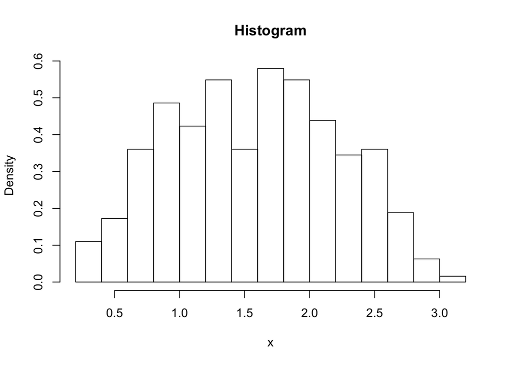

```r
hist(a[c],main = "Histogram",xlab = "x",freq = F)
```

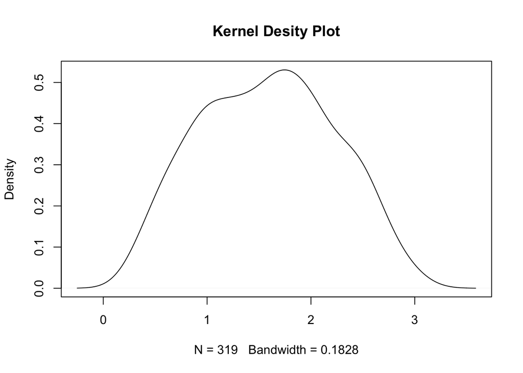

```r
plot(density(a[c]),main = "Kernel Desity Plot")
```

What is your acceptance rate?

Create a histogram of your generated (accepted) sample.

Plot a kernel density of the resulting (accepted) sample.

## Problem 5

Use rejection sampling to generate samples from the normal distribution, by using the folded-normal distribution method discussed in class.

The standard normal distribution has the pdf:

$$f(z) = \frac{1}{\sqrt{2\pi}} \exp{(-z^2/2)} \mbox{, for } z \in (-\infty, \infty)$$

The target distribution f(x) will be the positive half of the standard normal distribution, which will have PDF:

$$f(x) = 2 \times \frac{1}{\sqrt{2\pi}} \exp{(-x^2/2)}\mbox{, for } x \ge 0$$

Use an exponential distribution with lambda = 1 as your trial (proposal) distribution.

$$g(x) = e^{-x} \mbox{, for } x \ge 0$$

Find the optimal constant M that maximizes the acceptance rates for the rejection sampling design.

Implement the rejection sampling design as discussed in class.

- Use `runif` and inverse CDF to get a proposal value $X$ from the exponential distribution.
- Calculate the ratio: $\frac{f(X)}{M \times g(X)}$
- Use `runif` to generate $U$ to decide whether to accept or reject the proposed $X$.
- keep the accepted $X$
- Use `runif` to generate $S$ to decide whether the accepted $X$ will be positive or negative with probably 0.5.

Use the above algorithm to generate a vector of 200 random values from the normal distribution.

Create a histogram of your generated sample.

Create a QQ-norm plot.

```r
# Find the optimal constant M
set.seed(1234)
s <- seq(-0.05,3, by  = 0.001)
density <- function(x) ifelse(x < 0,0,2*(1/sqrt(2*pi))*exp(-((x^2)/2)))
propose <- function(x) ifelse(x < 0,0,exp(-x))

(M <- max(density(s)/propose(s),na.rm = TRUE))
```

[output not shown]

```r
rejec_s <- function(x){
        accept <- c()
        for(i in 1:x){
        u1 <- runif(1)
        j <- -log(u1)
        if(u1 <= (2*(1/sqrt(2*pi))*exp(-((j^2)/2)))/(M*j)){
                accept[i] <- j
        }else{
               accept[i] <- NA
        }
        }
        return(accept)
}
accepted <- rejec_s(500)
r_accept <- na.omit(accepted)
r_accept <- r_accept[1:200]
length(r_accept)
```

```
## [1] 200
```

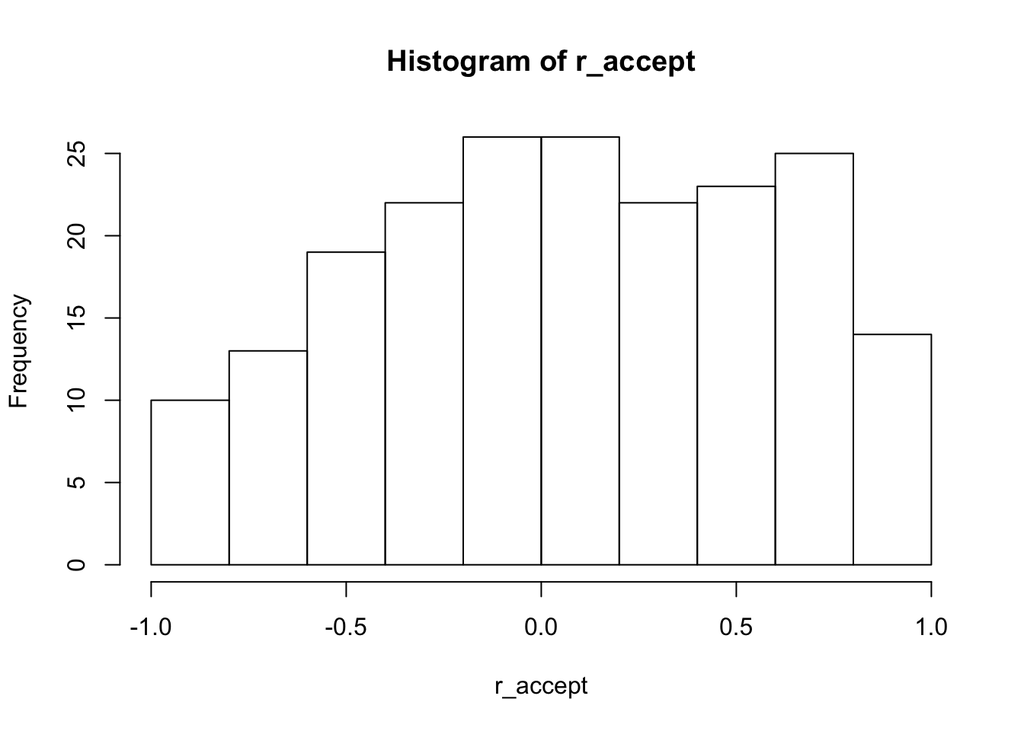

```r
s <- runif(length(r_accept),0,1)
s_minus <- s < 0.5
r_accept[s_minus] = - r_accept[s_minus]

hist(r_accept)
```

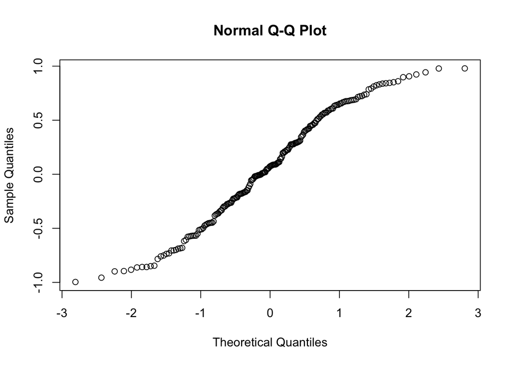

```r
qqnorm(r_accept)
```